# Storm Data Analysis

Akash Suresh

July 30, 2016

## Synopsis

In this project, data from National Weather Service is used to learn about the extent of damages, both health and economic, caused by the different natural events. The dataset used can be found [here](https://d396qusza40orc.cloudfront.net/repdata%2Fdata%2FStormData.csv.bz2). Also, the following links contain information about the dataset used,

1. National Weather Service [Storm Data Documentation](https://d396qusza40orc.cloudfront.net/repdata%2Fpeer2_doc%2Fpd01016005curr.pdf).
2. National Climatic Data Center Storm Events [FAQ](https://d396qusza40orc.cloudfront.net/repdata%2Fpeer2_doc%2FNCDC%20Storm%20Events-FAQ%20Page.pdf).

The projects answers the following two questions,

1. Across the United States, which types of events (as indicated in the EVTYPE variable) are most harmful with respect to population health?
2. Across the United States, which types of events have the greatest economic consequences?

Conclusions have been drawn after couple of small data preprocessing steps which is explained in detail in the next section.

## Data Preprocessing

After the working directory is set and the file is downloaded, load it into your R environment.

```r
if(!file.exists("stormData.csv.bz2")){
  download.file("https://d396qusza40orc.cloudfront.net/repdata%2Fdata%2FStormData.csv.bz2",
              destfile = "stormData.csv.bz2", mode = "wb")
}
myData <- read.csv(bzfile("stormData.csv.bz2"))
```

Load dplyr, ggplot2 libraries as it will be used later on.

```r
library(dplyr)
```

```r
library(ggplot2)
```

For answering the first question, only a small portion of the entire dataset suffices. We require the EVTYPE, FATALITIES and INJURIES. Select these columns before carrying out the operations.

```r
reqData <- myData[,c("EVTYPE", "FATALITIES", "INJURIES")]
```

Next, lets group by EVTYPE because we need to compare between the various events.

```r
groupByEvt <- group_by(reqData, EVTYPE)
groupByEvt <- summarize(groupByEvt, sum(FATALITIES), sum(INJURIES))
```

Since we have two counts, FATALITIES and INJURIES, lets do a separate analysis on each of those.

```r
## Extract information about fatalities
groupByEvtF <- groupByEvt[order(-groupByEvt$`sum(FATALITIES)`),]
groupByEvtF <- head(groupByEvtF, 10)[,c(1,2)]

## Extract information about injuries
groupByEvtI <- groupByEvt[order(-groupByEvt$`sum(INJURIES)`),]
groupByEvtI <- head(groupByEvtI, 10)[,c(1,3)]
```

Lets take a look at the data we have now.

```r
groupByEvtF
```

```
## # A tibble: 10 x 2
##            EVTYPE sum(FATALITIES)
##            <fctr>           <dbl>
## 1         TORNADO            5633
## 2  EXCESSIVE HEAT            1903
## 3     FLASH FLOOD             978
## 4            HEAT             937
## 5       LIGHTNING             816
## 6       TSTM WIND             504
## 7           FLOOD             470
## 8     RIP CURRENT             368
## 9       HIGH WIND             248
## 10      AVALANCHE             224
```

```r
groupByEvtI
```

```
## # A tibble: 10 x 2
##               EVTYPE sum(INJURIES)
##               <fctr>         <dbl>
## 1            TORNADO         91346
## 2          TSTM WIND          6957
## 3              FLOOD          6789
## 4     EXCESSIVE HEAT          6525
## 5          LIGHTNING          5230
## 6               HEAT          2100
## 7          ICE STORM          1975
## 8        FLASH FLOOD          1777
## 9  THUNDERSTORM WIND          1488
## 10              HAIL          1361
```

### 10 Most Fatal Events

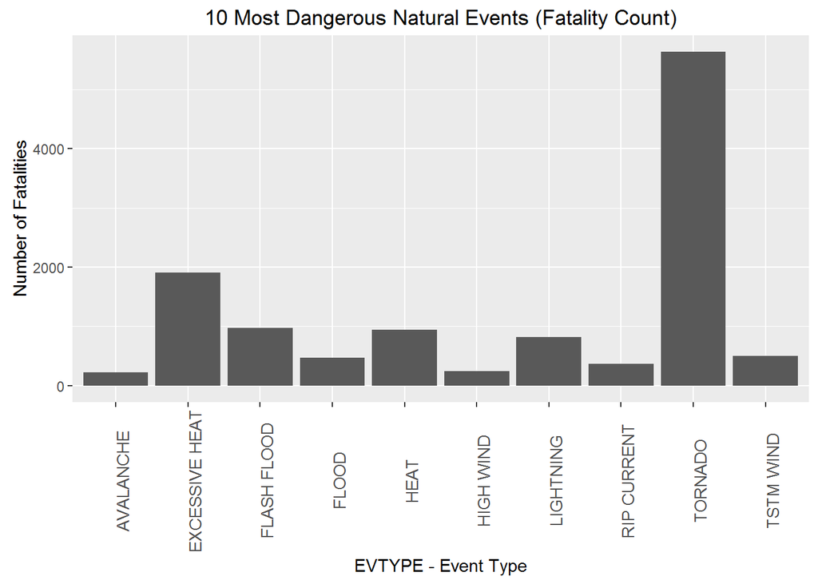

```r
g <- ggplot(groupByEvtF, aes(EVTYPE, `sum(FATALITIES)`))
g <- g + geom_bar(stat = "identity")
g <- g + theme(axis.text.x = element_text(angle=90, vjust=1, size = 10))
g <- g + labs(x = "EVTYPE - Event Type", y = "Number of Fatalities", title = "10 Most Dangerous Natural Events (Fatality Count)")
g
```

### 10 Most Dangerous Events (Injuries)

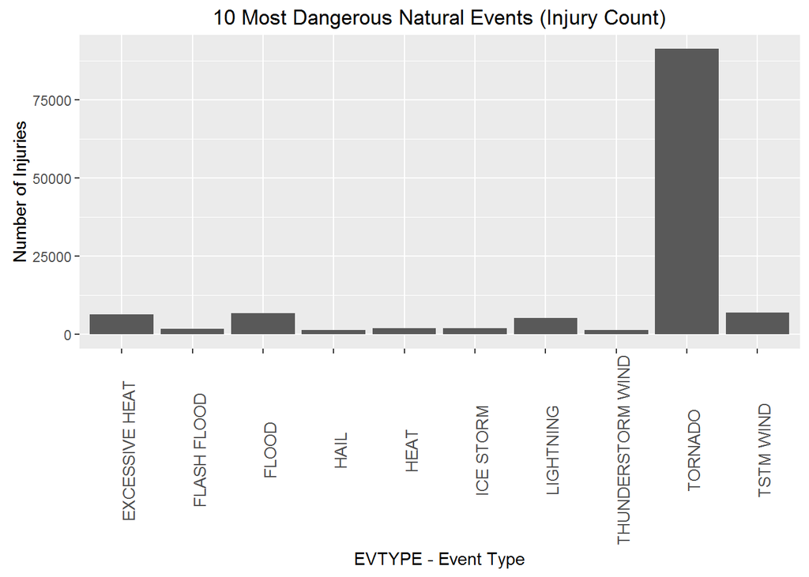

```r
g <- ggplot(groupByEvtI, aes(EVTYPE, `sum(INJURIES)`))
g <- g + geom_bar(stat = "identity")
g <- g + theme(axis.text.x = element_text(angle=90, vjust=1, size = 10))
g <- g + labs(x = "EVTYPE - Event Type", y = "Number of Injuries", title = "10 Most Dangerous Natural Events (Injury Count)")
g
```

### 10 Most Expensive Event Types

We know that the extent of economic damages are denoted by the features, PROPDMG and PROPDMGEXP, where the former gives a value and the latter describes whether the value in thousands (K), millions (M) or billions (B). Similarly, there are CROPDMG and CROPDMGEXP. For ease of manipulation lets create a new variable that contians the full amount. For this we will create a new feature called TOTDMG. Before that, lets also load the data and select only the required columns. In this case, EVTYPE, PROPDMG, CROPDMG, CROPDMGEXP and PROPDMGEXP.

```r
reqData <- myData[,c("EVTYPE","PROPDMG","PROPDMGEXP","CROPDMG","CROPDMGEXP")]
groupByEvt <- group_by(reqData, EVTYPE)
groupByEvt <- mutate(groupByEvt, TOTDMGP = ifelse(PROPDMGEXP == "M", PROPDMG*10^6, ifelse(PROPDMGEXP == "K", PROPDMG*10^3, PROPDMG*10^9)))
groupByEvt <- mutate(groupByEvt, TOTDMGC = ifelse(CROPDMGEXP == "M", CROPDMG*10^6, ifelse(CROPDMGEXP == "K", CROPDMG*10^3, CROPDMG*10^9)))
groupByEvt <- mutate(groupByEvt, TOTDMG = TOTDMGP + TOTDMGC)
groupByEvt <- summarize(groupByEvt, sum(TOTDMG))

groupByEvt <- groupByEvt[order(-groupByEvt$`sum(TOTDMG)`),]
groupByEvt <- head(groupByEvt, 10)
```

Lets look at the data.

```r
groupByEvt
```

```
## # A tibble: 10 x 2
##                EVTYPE  sum(TOTDMG)
##                <fctr>        <dbl>
## 1  THUNDERSTORM WINDS 6.269624e+12
## 2                HAIL 7.913529e+11
## 3         FLASH FLOOD 5.746621e+11
## 4             TORNADO 5.275406e+11
## 5           LIGHTNING 1.676408e+11
## 6               FLOOD 1.573197e+11
## 7          HIGH TIDES 1.500000e+11
## 8   THUNDERSTORM WIND 1.478980e+11
## 9          HIGH WINDS 9.864904e+10
## 10  HURRICANE/TYPHOON 7.191371e+10
```

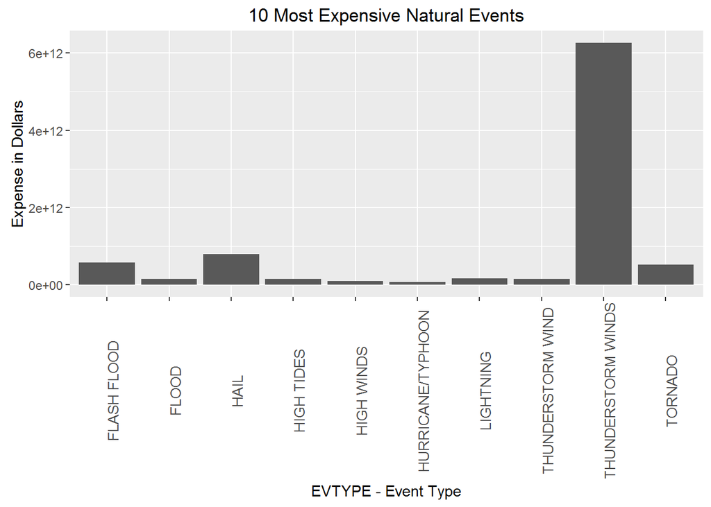

```r
g <- ggplot(groupByEvt, aes(EVTYPE, `sum(TOTDMG)`))
g <- g + geom_bar(stat = "identity")
g <- g + theme(axis.text.x = element_text(angle=90, vjust=1, size = 10))
g <- g + labs(x = "EVTYPE - Event Type", y = "Expense in Dollars", title = "10 Most Expensive Natural Events")
g
```

## Results

It is evident from the above plots and figures that the Tornado is the most dangerous natural event according to the dataset in terms of the damage caused to human health. Using the variables, FATALITIES and INJURIES, the extent of damage to humans was measured. PROPDMG, CROPDMG, PROPDMGEXP, CROPDMGEXP are used to measure economic damage. Thunderstorms are the most expensive events, with some individual values even in Billions.